# Participation Rates of GitHub Projects

### Participation Levels

Experiment 2: Distribution of 5 random samples for 100 high participation projects per above TODO: Only checking 1 sample due to MVP time contraints

```r
participation_rate_event_types <- readRDS("participation_rate_event_types.rds")

high_participation_rate_event_types <- participation_rate_event_types %>%
  filter(participation_level == "High") %>%
  mutate(total_events = sum(num_events),
         total_actors = sum(num_actors),
         dataset = "population",
         events_prop = round(num_events/total_events,2),
         actors_prop = round(num_actors/total_actors,2))

high_participation_rate_event_types <- high_participation_rate_event_types %>%
  select(type, actors_prop, events_prop, total_events_per_actor, dataset)
```

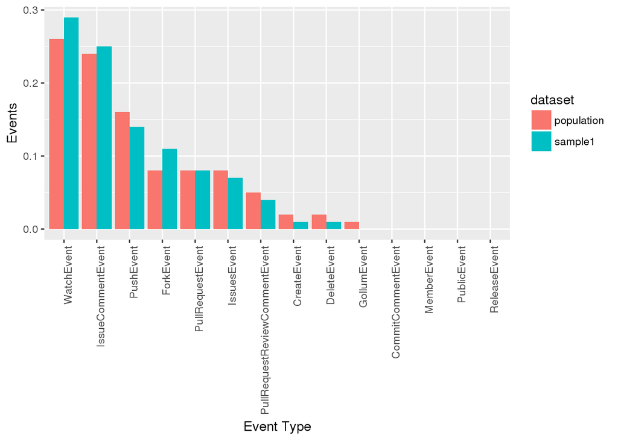

```r
high_sample1 <- readRDS("high_sample_1.rds")
high_sample1 <- high_sample1 %>%
  mutate(dataset="sample1",
         total_events = sum(num_events),
         total_actors=sum(num_actors))

high_samples <- high_sample1 # for multiple samples: bind_rows(high_sample1, high_sample2)

high_sample_event_types <- high_samples %>%
  group_by(dataset, type) %>%
  summarise(
    sum_events = sum(num_events),
    sum_actors = sum(num_actors),
    total_events_per_actor = sum_events/sum_actors,
    events_prop = round(sum_events/min(total_events),2),
    actors_prop = round(sum_actors/min(total_actors),2)) %>%
  select(type, events_prop, actors_prop, total_events_per_actor, dataset)

high_participation_distribution <- bind_rows(high_sample_event_types, high_participation_rate_event_types)

high_participation_distribution$type <- factor(high_participation_distribution$type,
  levels = unique(high_participation_distribution$type[order(high_participation_distribution$events_prop, decreasing=TRUE)]))

ggplot(data = high_participation_distribution, aes(x=type, y=events_prop, fill=dataset)) +
  geom_bar(stat="identity", position="dodge") +
  ylab("Events") +
  xlab("Event Type") +
  scale_y_continuous(labels=function(n){format(n, scientific = FALSE)}) +
  theme(axis.text.x = element_text(angle = 90, hjust = 1))
```

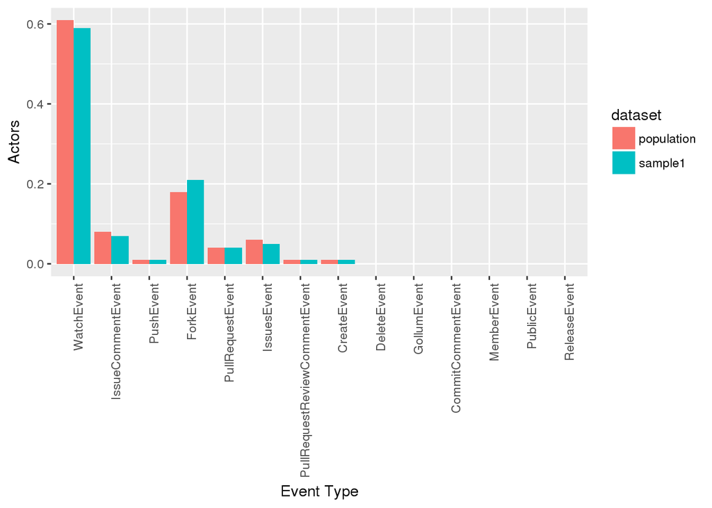

```r
ggplot(data = high_participation_distribution, aes(x=type, y=actors_prop, fill=dataset)) +
  geom_bar(stat="identity", position="dodge") +
  ylab("Actors") +
  xlab("Event Type") +
  scale_y_continuous(labels=function(n){format(n, scientific = FALSE)}) +
  theme(axis.text.x = element_text(angle = 90, hjust = 1))
```

TODO: To get an accurate count of number of actors, we need to get different data since events of different types could be associated with the same actor.

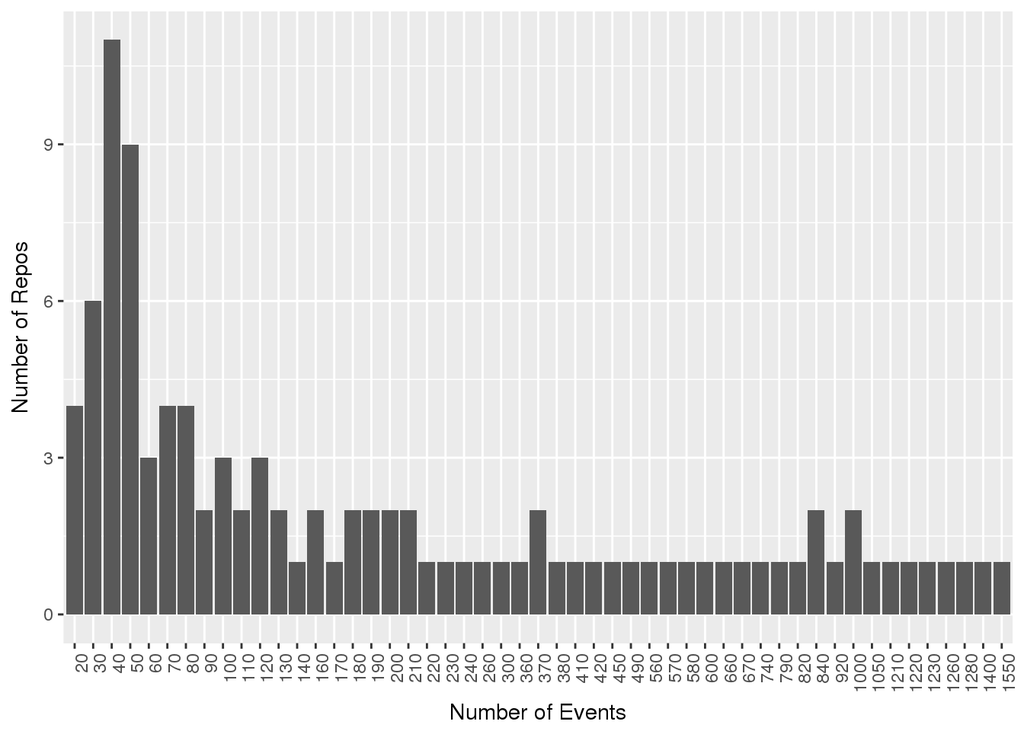

```r
high_summary_by_repo <- high_samples %>%
  group_by(repo_name) %>%
  summarise(
    total_repo_actors = round(sum(num_actors), -1),
    total_repo_events = round(sum(num_events), -1)
  )

high_summary_by_events <- high_summary_by_repo %>%
  group_by(total_repo_events) %>%
  summarise(num_repos = n())

ggplot(data = high_summary_by_events, aes(y=num_repos, x=factor(total_repo_events))) +
  geom_bar(stat="identity", position = "dodge") +
  ylab("Number of Repos") +
  xlab("Number of Events") +
  theme(axis.text.x = element_text(angle = 90, hjust = 1))
```

Experiment 3: Distribution of 5 random samples for 100 medium participation projects per above TODO: Only checking 1 sample due to MVP time contraints

```r
participation_rate_event_types <- readRDS("participation_rate_event_types.rds")

med_participation_rate_event_types <- participation_rate_event_types %>%
  filter(participation_level == "Medium") %>%
  mutate(total_events = sum(num_events),
         total_actors = sum(num_actors),
         dataset = "population",
         events_prop = round(num_events/total_events,2),
         actors_prop = round(num_actors/total_actors,2))

med_participation_rate_event_types <- med_participation_rate_event_types %>%
  select(type, actors_prop, events_prop, total_events_per_actor, dataset)
```

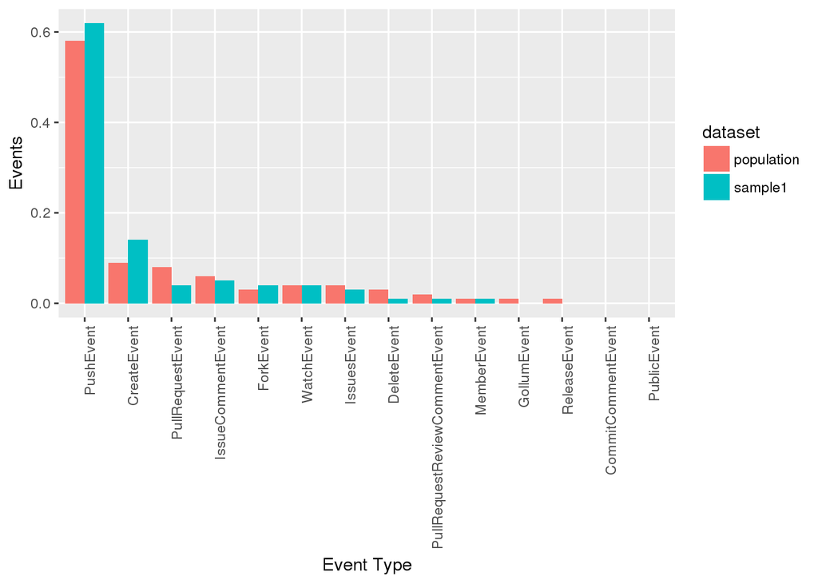

```r
med_sample1 <- readRDS("med_sample_1.rds")
med_sample1 <- med_sample1 %>%
  mutate(dataset="sample1",
         total_events = sum(num_events),
         total_actors=sum(num_actors))

med_samples <- med_sample1 # for multiple samples: bind_rows(med_sample1, med_sample2)

med_sample_event_types <- med_samples %>%
  group_by(dataset, type) %>%
  summarise(
    sum_events = sum(num_events),
    sum_actors = sum(num_actors),
    total_events_per_actor = sum_events/sum_actors,
    events_prop = round(sum_events/min(total_events),2),
    actors_prop = round(sum_actors/min(total_actors),2)) %>%
  select(type, events_prop, actors_prop, total_events_per_actor, dataset)

med_participation_distribution <- bind_rows(med_sample_event_types, med_participation_rate_event_types)

med_participation_distribution$type <- factor(med_participation_distribution$type,
  levels = unique(med_participation_distribution$type[order(med_participation_distribution$events_prop, decreasing=TRUE)]))

ggplot(data = med_participation_distribution, aes(x=type, y=events_prop, fill=dataset)) +
  geom_bar(stat="identity", position="dodge") +
  ylab("Events") +
  xlab("Event Type") +
  scale_y_continuous(labels=function(n){format(n, scientific = FALSE)}) +
  theme(axis.text.x = element_text(angle = 90, hjust = 1))
```

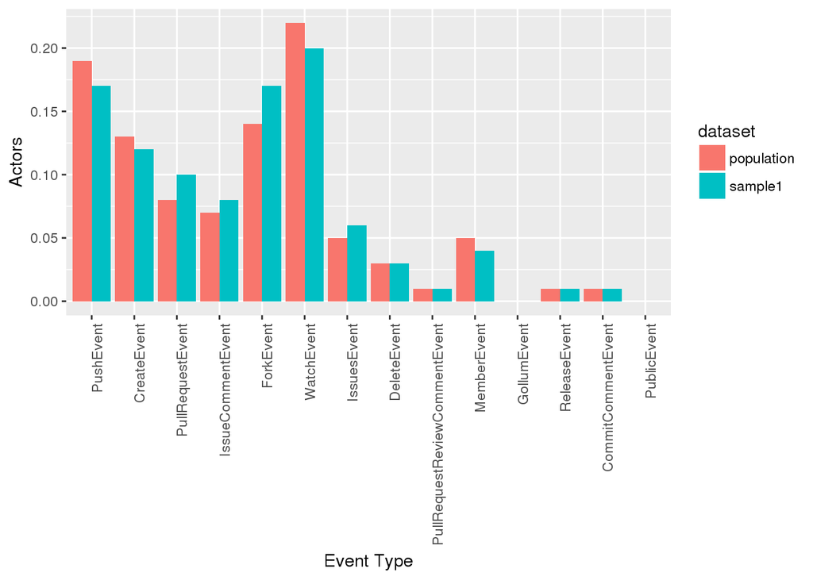

```r
ggplot(data = med_participation_distribution, aes(x=type, y=actors_prop, fill=dataset)) +
  geom_bar(stat="identity", position="dodge") +
  ylab("Actors") +
  xlab("Event Type") +
  scale_y_continuous(labels=function(n){format(n, scientific = FALSE)}) +
  theme(axis.text.x = element_text(angle = 90, hjust = 1))
```

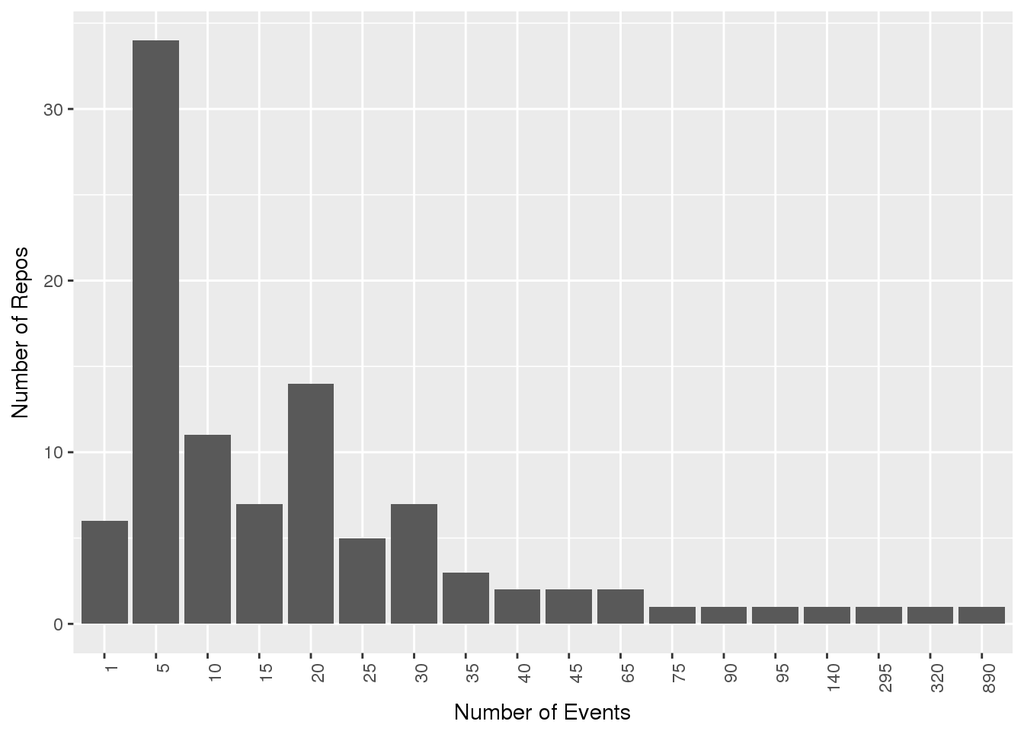

```r
med_summary_by_repo <- med_samples %>%
  group_by(repo_name) %>%
  summarise(
    total_repo_events = 5*round(sum(num_events)/5)
  )
med_summary_by_repo <- med_summary_by_repo %>%
  mutate(total_repo_events = ifelse(total_repo_events == 0, 1, total_repo_events))

med_summary_by_events <- med_summary_by_repo %>%
  group_by(total_repo_events) %>%
  summarise(num_repos = n())

ggplot(data = med_summary_by_events, aes(y=num_repos, x=factor(total_repo_events))) +
  geom_bar(stat="identity", position = "dodge") +
  ylab("Number of Repos") +
  xlab("Number of Events") +
  theme(axis.text.x = element_text(angle = 90, hjust = 1))
```

Experiment 4: Distribution of 5 random samples for 100 low participation projects per above TODO: Not checking this one due to time constraints and a problem with the samples

### Specific Event Types

Experiment 5: Distribution of 5 random samples for 100 Watch Events (High Participation) TODO: Skipping due to MVP time contraints

```r
# TODO proportion of events, proportion of actors
```

Experiment 6: Distribution of 5 random samples for 100 Pull Request Events (Medium Participation) TODO: Skipping due to MVP time contraints

```r
# TODO proportion of events, proportion of actors
```

Experiment 7: Distribution of 5 random samples for 100 Create Events (Low Participation) TODO: Skipping due to MVP time contraints

```r
# TODO proportion of events, proportion of actors
```

Experiment 8: Distribution of 5 random samples for 100 Push Events (Low Participation) TODO: Skipping due to MVP time contraints

```r
# TODO proportion of events, proportion of actors
```

## Preliminary Conclusions

Given the incomplete state of the analysis, only preliminary conclusions can be made at this time.

For BonnyCI lead generation purposes, I will further examine the samples from high and medium participation projects using additional Github data in a future report.